# Laboratorio 1- Análisis estadístico de datos extremales

### Carolina Crisci, Gonzalo Perera, Angel Segura

# Introducción

En este práctico veremos la forma de las diferentes distribuciones **extremales** mencionadas en el teórico y luego una simulación para observar la convergencia de una serie de datos simulados a las distribuciones extremales.

## Distrubiciones extremales

Veremos a continuación las distribuciones extremales trabajadas en el teórico.

### Weibull

Recordemos que cuando tomamos los máximos de las variables *iid* con un rango acotado, la distribución resultante por la cual se puede aproximar es la de *Weibull*. En este caso, y en el resto del LAB, *exp()* y *e* son la función exponencial. La función de orden $\alpha$ es:
$$\Psi_{\alpha}(x)= exp(-(-x)^{\alpha}) ~~~~para~ todo~~~ x < 0$$
Por una única vez, calculemos la distribución de forma “manual” en el **R** para convencernos de la forma de la función de distribución de Weibull ($\Psi$). Para eso generaremos un vector auxiliar de valores “x” y la distribución (“F(x)”). En **R** la definición de la distribución es sutilmente diferente a la que vimos en el teórico (definida para positivos), pero totalmente convertible con dos cambios de signo. La función que calcula la probabilidad de una distribución Weibull es *pweibull()*. Pueden ver la definición de **R** utilizando *help(pweibull)* o *?pweibull*.En **R** podemos saber la forma y valores de esta distribución con una función implementada en un paquete base *{stats}*. La función es *pweibull* y lleva como argumentos un vector de cuantiles ( *q* ), un argumento de forma ( *shape* ) y otro de escala ( *scale* ). Recordemos que la función *plot* utiliza 2 argumentos centrales ( *x* e *y* ) y podemos fijar los límites del gráfico ( *xlim* e *ylim*), el tipo de gráfico ( *type*) y las etiquetas de los ejes X e Y ( *xlab* e *ylab*).

Primero generaremos un vector de numeros auxiliares equiespaciados y lo nombraremos (*“x_aux”*). Luego definiremos un orden ($alpha=\alpha$) de la Weibull y graficaremos la función.

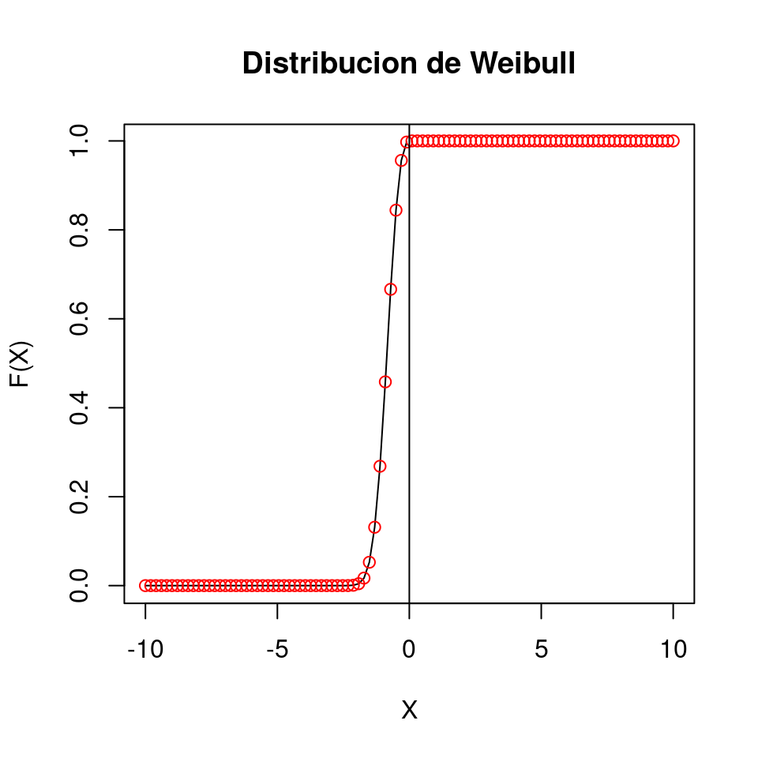

```r
 x_aux<-seq(-10, 10, length=100)

alpha<- 2.6 # definimos un alfa cualquiera (>0)
plot(x_aux, exp(-(-x_aux)^alpha), type="l", log="", ylab="F(X)", xlab="X", main="Distribucion de Weibull") # recordemos que la definimos para X<0, luego vale 1
points(x_aux, 1-pweibull(-x_aux, shape=alpha, scale=1), col="red")
abline(v=0)
```

Veamos ahora la forma de un par de distribuciones cambiando el parámetro de orden ($\alpha$), que en la función *pweibull* de **R** se nombra como *shape* y que define el orden de la distribución.

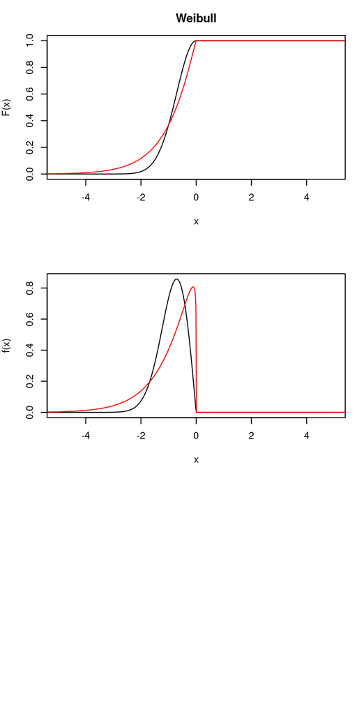

```r
x_aux<- seq(-10,10, length=1000)

par(mfrow=c(3,1), mar=c(5,4,3,1))
plot(x_aux, 1-pweibull(q=-x_aux, shape=2, scale=1) ,xlim=c(-5,5), type="l", ylab="F(x)", xlab="x", main="Weibull")
lines(x_aux, 1-pweibull(q=-x_aux, shape=1.1, scale=1), col="red")

plot(x_aux, dweibull(x=-x_aux, shape=2, scale=1, log = FALSE) ,xlim=c(-5,5), type="l", ylab="f(x)", xlab="x")
lines(x_aux, dweibull(x=-x_aux, shape=1.1, scale=1, log = FALSE), col="red") #
```

En **R** podemos también generar numeros aleatórios (técnicamente pseudo-aleatorios) de una distribución extremal. Estos simuladores de números aleatórios son útiles para comparar contra distribuciones nulas, generar modelos sintéticos para probar algorítmos, etc…  
Para lxs que venimos de la rama mas aplicada, muchas veces nos ayudan a entender como funcionan los modelos y a verificar si nuestra intuición es acertada respecto a la escala de ajuste de los parámetros entre otras útiles. Generaremos 2 series de 1000 números aleatórios con la función *rweibull*, que tiene como parámetro el número de datos que se necesitan y la forma (*shape*) de la distribución. Luego haremos un grafico con la densidad empírica (esto es similar a un histograma) de estos vectores.

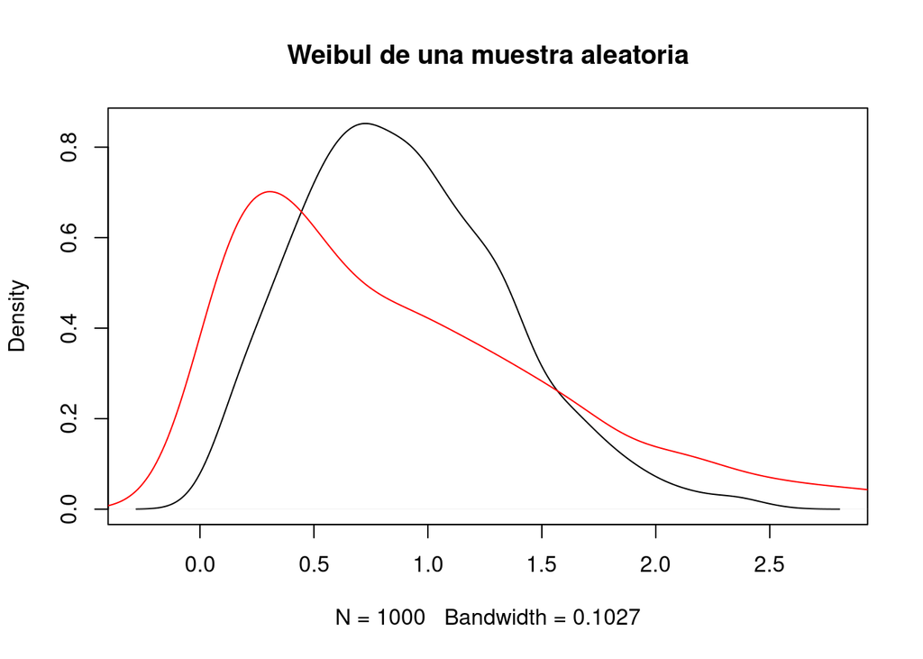

```r
randomWeibull1<-rweibull(1000, shape=2)
randomWeibull2<-rweibull(1000, shape=1.1)

plot(density(randomWeibull1), main="Weibul de una muestra aleatoria")
lines(density(randomWeibull2),col="red")
```

### Gumbel

Cuando tomamos los máximos de variables no acotadas pero que tienen colas livianas (ej. la distribución tiene probabilidades muy bajas de tomar valores lejos de la media) los mismos convergen a una distribución asintótica extremal de *Gumbel* que se define por

$$\Lambda(x)= exp(-e^{-x}) ~~~~ x \in \mathbb{R}$$
Para simular distribuciones de Gumbel, utilizamos el paquete *{evd}* que instalamos una vez y luego lo llamamos con la función *{require}*. Si no lo tenemos instalado, por una única vez, debemos llamar la función *install.packages()*.

```r
#install.packages("evd")
require(evd)
```

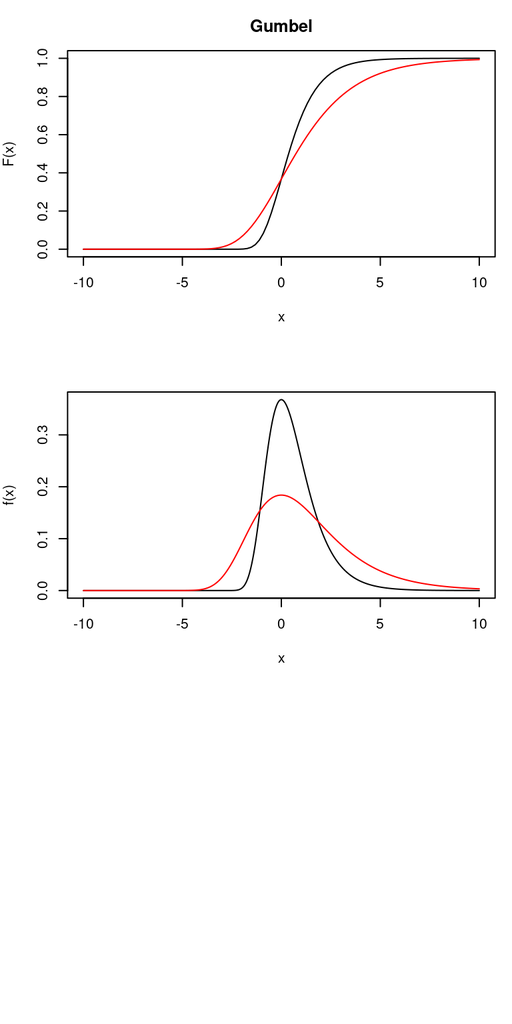

```r
x_aux<- seq(-10,10, length=1000)

par(mfrow=c(3,1), mar=c(5,4,3,1))
plot(seq(-10,10,length=100), pgumbel(q=seq(-10,10,length=100), loc=0, scale=1) ,xlim=c(-10,10), type="l", ylab="F(x)", xlab="x", main="Gumbel")
lines(seq(-10,10,length=100), pgumbel(q=seq(-10,10,length=100), loc=0, scale=2), col="red")

plot(x_aux, dgumbel(x=x_aux, loc=0, scale=1, log = FALSE) ,xlim=c(-10,10), type="l", ylab="f(x)", xlab="x")
lines(x_aux, dgumbel(x=x_aux, loc=0, scale=2, log = FALSE), col="red") # Cambio la escala de la Gumbel
```

De la misma manera, podemos simular números aleatorios de una distribución de Gumbel utilizando la función *rgumbel*. Si calculamos el valor esperado y el desvío estandard de estos valores observados y tenemos una muestra lo suficientemente grande, podremos comparar los resultados con los esperados de forma teórica.

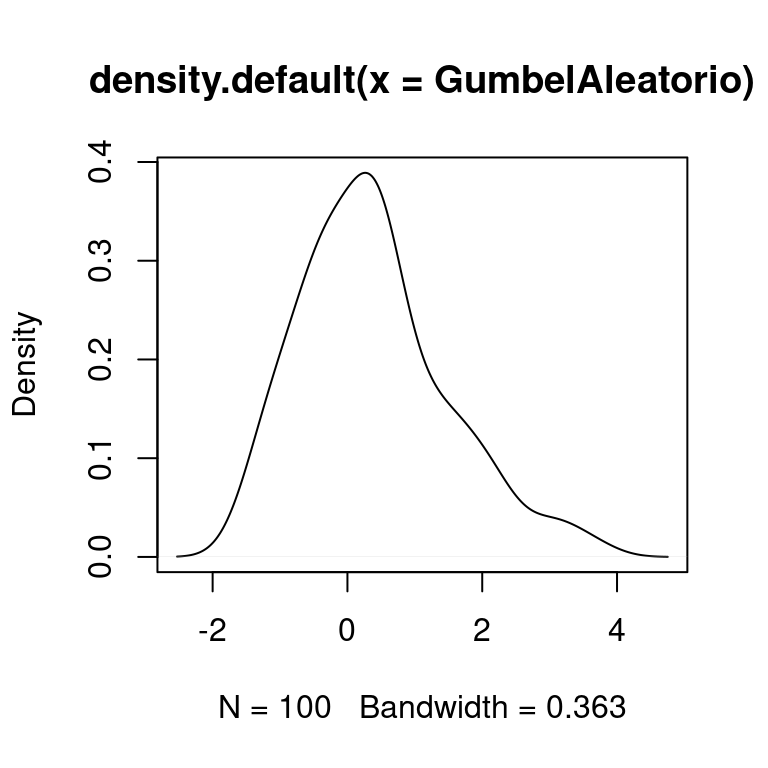

```r
# Podemos simular 100 datos aleatorios de una distribución Gumbel
GumbelAleatorio<-rgumbel(100)

plot(density(GumbelAleatorio))
```

```r
-digamma(1) # Constante de Euler-Mascheroni
```

```
## [1] 0.5772157
```

```r
mean(rgumbel(1000))
```

```
## [1] 0.6452415
```

```r
sd(rgumbel(1000)) # Compare con lo expresado en el teórico
```

```
## [1] 1.320444
```

### Frechet

Esta tercera clase de variables incluyen a las distribuciones no acotadas, pero de colas pesadas. Es decir que tienen una probabilidad alta de presentar valores alejados de la media o la mediana (ej. la Cauchy). En estos casos, la distribución de sus máximos es la *Frechet*. Veamos la forma de la distribución y su densidad de probabilidad.
$$\Phi_{\alpha}(x)= exp(-x^{-\alpha}) ~~~~~~ x>0$$
Grafiquemos esta distribución para dos valores diferentes de $\alpha$.

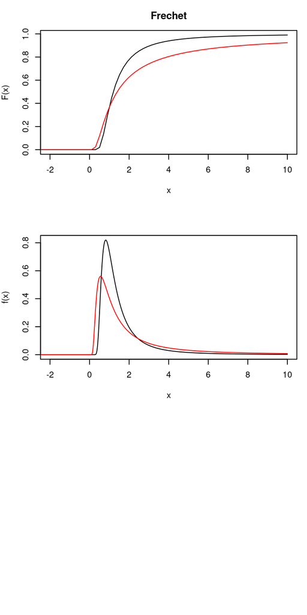

```r
x_aux<- seq(-10,10, length=1000)

par(mfrow=c(3,1), mar=c(5,4,3,1))
plot(seq(-10,10,length=100), pfrechet(q=seq(-10,10,length=100), shape=2, scale=1) ,xlim=c(-2,10), type="l", ylab="F(x)", xlab="x", main="Frechet")
lines(seq(-10,10,length=100), pfrechet(q=seq(-10,10,length=100), shape=1.1, scale=1),col= "red")

plot(x_aux, dfrechet(x=x_aux, shape=2, scale=1, log = FALSE) ,xlim=c(-2,10), type="l", ylab="f(x)", xlab="x")
lines(x_aux, dfrechet(x=x_aux, shape=1.1, scale=1, log = FALSE), col="red") #
```

### GEV Distribución Extremal Generalizada (DEG)

Esta distribución representa una generalización de las anteriores, y se define como:
$$GEV(t)(\mu,\beta,\xi)= exp(-(1 + \xi(t-\mu)/\beta)^{-1/\xi} ~~~ si~~ \xi \neq 0, ~~~ para ~~todo ~~t ~~ cuando ~~ 1 + \xi(t-\mu)/\beta >0$$
$$GEV(t)(\mu,\beta,\xi)= exp(-exp(-(t-\mu)/\beta)) ~~~si~~\xi=0 ~~ para ~~ todo ~~ t$$
Recordemos que esta distribución corresponde a Weibull cuando $\xi<0$, a Gumbell cuando $\xi = 0$ y a Frechet cuando $\xi >0$. Veremos más adelante que podemos estimar el valor de $\xi$ y evaluar si el intervalo de confianza incluye al cero o no para decidir que tipo de distribución tenemos. Como las anteriores, esta distribución se puede simular en **R**. Simulemos las distribuciones con diferente $\xi$ para ver como se comportan. A efectos visuales solamente simularemos la función de densidad (f(x)) de una GEV con parámetro $\xi=2$ y $\xi=0$ que siguen una Frechet y una Gumbell respectivamente.

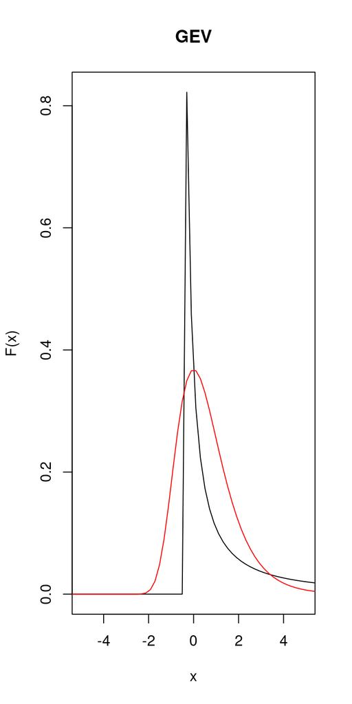

```r
x_aux<- seq(-10,10, length=1000)

plot(seq(-10,10,length=100), dgev(x=seq(-10,10,length=100), shape=2, scale=1) ,xlim=c(-5,5), type="l", ylab="F(x)", xlab="x", main="GEV")
lines(seq(-10,10,length=100), dgev(x=seq(-10,10,length=100), shape=0, scale=1),col= "red")
```

Hemos conocido un primer acercamiento a como visualizar y operar con las distribuciones extremales asintóticas y la generalizada. Ahora veamos como a partir de datos de mediciones frecuentes podemos operar para extraer los máximos y como ajustar estas distribuciones y evaluar su desempeño.

## Simulaciones

En esta sección veremos cuales son las distribuciones que se ajustan a diferentes tipos de distribuciones generadoras.

### UNIFORME

```r
# Esta funcion (require) carga paquetes de funciones pre-establecidas y utiles para analisis de extremos
require(ismev)
```

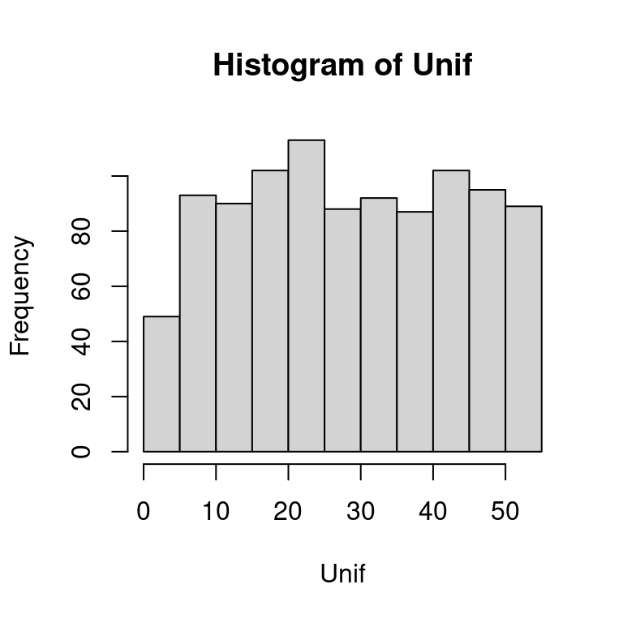

```r
# 1.1
# simulamos 1000 datos tomados de una distribucion uniforme entre 2 y 55
set.seed(69)
Unif<-runif(1000, 2, 55)

hist(Unif)
```

```r
max(Unif)
```

```
## [1] 54.99179
```

```r
min(Unif)
```

```
## [1] 2.007008
```

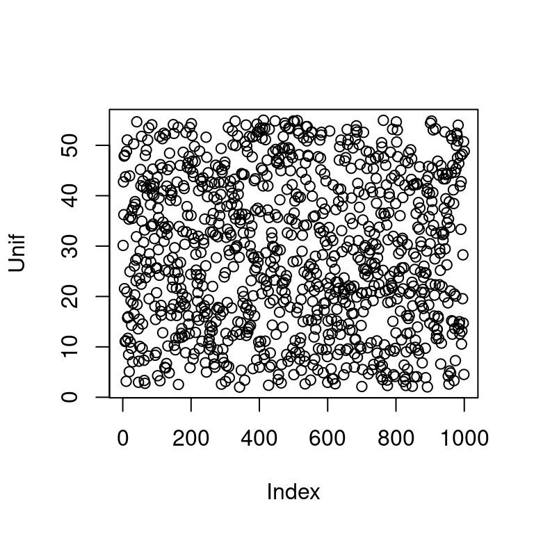

```r
plot(Unif, type="p")
```

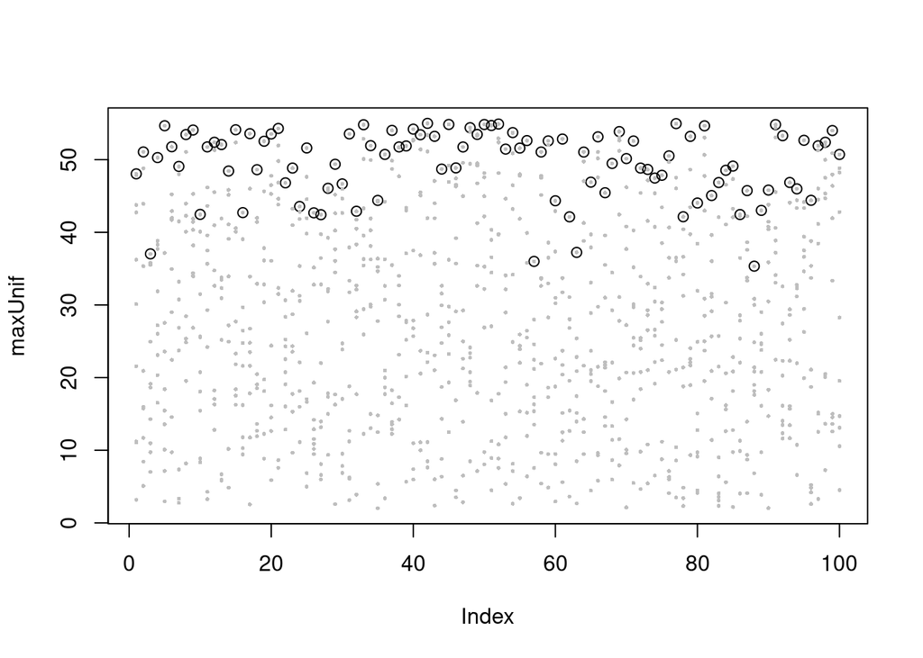

```r
# Tomemos los maximos de periodos que incluyen 10 registros cada uno
selPeriodo<-as.factor(rep(1:100, each=10)) # Genera variable auxiliar que marca bins de 10 registros
# La capacidad de anidar funciones en R para hacer calculos con bases complejas es muy grande.
maxUnif<-unlist(lapply( split(Unif, selPeriodo), max))# Aqui utilizamos en un mismo renglon las funciones unlist, lapply, split y max (poner ?unlist o help(unlist))

plot(maxUnif, ylim=c(2,55))
points(as.numeric(selPeriodo), Unif, pch=16, col="gray", cex=0.4)
```

```r
# Segun el Teorema de Fischer-Tippet-Gnedenko (FTG), Teorema 3, pg 12 y por la Observación 9 pg 13, debería ajustar bien una Weibull- por que la variable generadora es acotada
# Que en el caso de la distribucion de valores extremos generalizada (GEV, pg 34), corresponde a un valor del indice negativo.
# Esta funcion ajusta por maxima verosimilitud los parametros de posicion, escala e indice
modUnif<-gev.fit(maxUnif) # la funcion gev.fit ajusta una GEV por mve y lo salva en el objeto "modUnif"
```

```
## $conv
## [1] 0
##
## $nllh
## [1] 270.0331
##
## $mle
## [1] 49.4491181  5.3686186 -0.9682121
##
## $se
## [1] 8.439391e-02 7.672301e-02 2.000270e-06
```

```r
str(modUnif)
```

```
## List of 10
##  $ trans: logi FALSE
##  $ model:List of 3
##   ..$ : NULL
##   ..$ : NULL
##   ..$ : NULL
##  $ link : chr "c(identity, identity, identity)"
##  $ conv : int 0
##  $ nllh : num 270
##  $ data : Named num [1:100] 48 51.1 37 50.3 54.7 ...
##   ..- attr(*, "names")= chr [1:100] "1" "2" "3" "4" ...
##  $ mle  : num [1:3] 49.449 5.369 -0.968
##  $ cov  : num [1:3, 1:3] 7.12e-03 -6.44e-03 -1.00e-11 -6.44e-03 5.89e-03 ...
##  $ se   : num [1:3] 0.084394 0.076723 0.000002
##  $ vals : num [1:100, 1:3] 49.4 49.4 49.4 49.4 49.4 ...
##  - attr(*, "class")= chr "gev.fit"
```

```r
modUnif$mle
```

```
## [1] 49.4491181  5.3686186 -0.9682121
```

```r
data.frame(parameter=c("posicion", "escala","indice"), Estimado=round(modUnif$mle,3), SE=modUnif$se)
```

```
##   parameter Estimado           SE
## 1  posicion   49.449 8.439391e-02
## 2    escala    5.369 7.672301e-02
## 3    indice   -0.968 2.000270e-06
```

```r
#IdC95= Estimado +- (1.96 * SE)
```

Claramente el indice ($\xi<0$) por lo que estamos ante una distribución extremal Weibull, que corresponde a tomar los máximos de una variable acotado (como es el caso de la Uniforme que simulamos).

## NORMAL

Ahora veamos lo mismo pero para una variable aleatoria que proviene de una distribucion Normal o Gaussiana.

¿Cuál espera que sea la distribución extremal asintotica (DEA)? ¿como se traduce eso en el valor esperado del índice de una GEV?

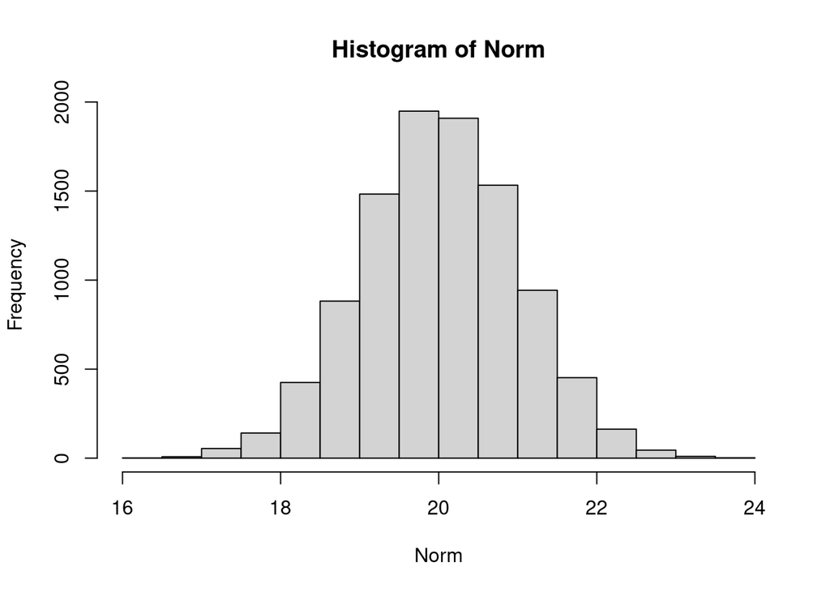

```r
set.seed(32)
Norm<-rnorm(10000, 20, 1)
hist(Norm)
```

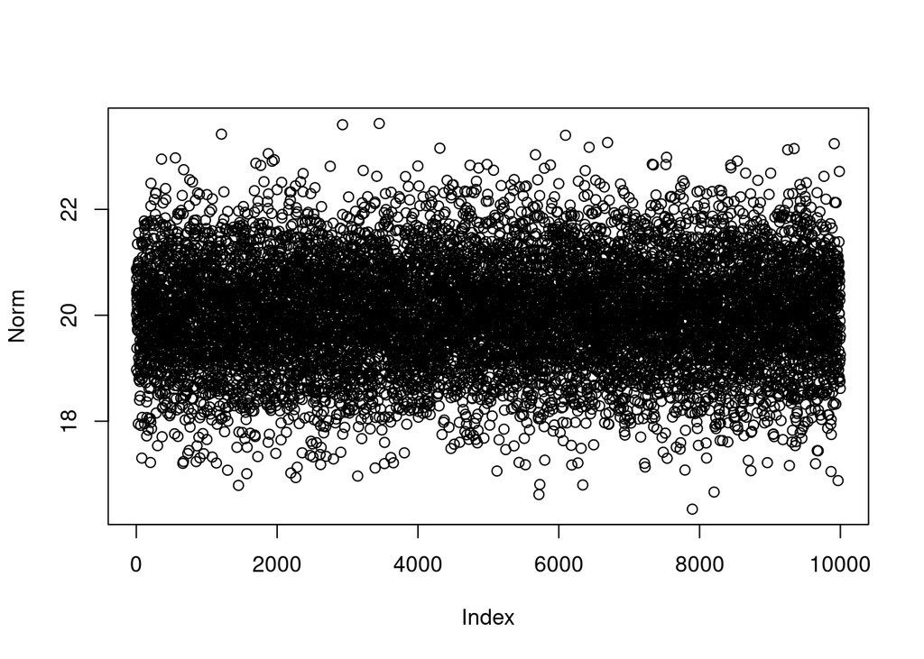

```r
plot(Norm, type="p")
```

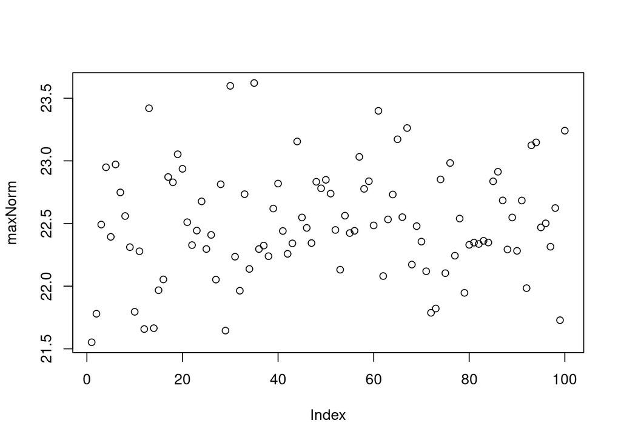

```r
# Tomemos los maximos de periodos de 10 registros cada uno
selPeriodo<-as.factor(rep(1:100, each=100))
maxNorm<-unlist(lapply( split(Norm, selPeriodo), max))

plot(maxNorm)
```

```r
# ¿Cual es el valor esperado del indice?
modNorm<-gev.fit(maxNorm)
```

```
## $conv
## [1] 0
##
## $nllh
## [1] 58.30997
##
## $mle
## [1] 22.3374486  0.4217606 -0.2266639
##
## $se
## [1] 0.04645616 0.03226844 0.06136402
```

```r
data.frame(parameter=c("posicion", "escala","indice"), Estimate=round(modNorm$mle,3), SE=modNorm$se)
```

```
##   parameter Estimate         SE
## 1  posicion   22.337 0.04645616
## 2    escala    0.422 0.03226844
## 3    indice   -0.227 0.06136402
```

```r
modNorm$mle[3]+ 1.96* modNorm$se[3]
```

```
## [1] -0.1063905
```

```r
modNorm$mle[3]- 1.96* modNorm$se[3]
```

```
## [1] -0.3469374
```

Vemos que a pesar que debería sugerirnos una distribución Gumbell, el indice ($\xi<0$) lo que sugiere una distribución acotada de Weibull. Aquí el número de datos necesario para evaluar diferencias sutiles es importante y más cuando se trabaja con los máximos en determinado periodo, que representan una parte de la distribución.

## MEZCLA DE DISTRIBUCIONES (pg 26 Teórico)

Veamos que acontece cuando tomamos muestras que provienen de dos DEA independientes (X, Y). En este caso tomaremos una Weibull y una Frechet. Por favor, antes de ver los resultados, revisen el teórico para predecir que esperamos de esa mezcla de distribuciones extremales.

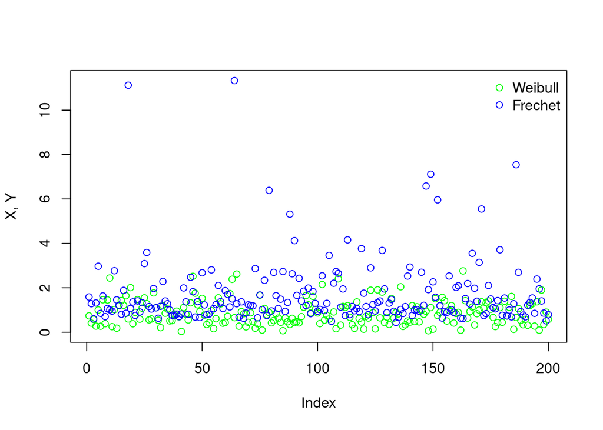

```r
require(evd)
n=200
set.seed(69)
randomWeibull<-rweibull(n=n, shape=1.5, scale=1)
randomFrechet<-rfrechet(n=n, loc=0, shape= 2, scale=1) # loc es posicion, shape= es el parametro de forma (indice), scale= es la variabilidad

MixtureDist<-cbind(randomWeibull, randomFrechet)

plot(randomWeibull, col="green", ylim=c(0, max(MixtureDist)), ylab="X, Y")
points(randomFrechet, col="blue")
legend("topright",legend=c("Weibull", "Frechet"), col=c("green","blue"), bty="n", pch=1)
```

```r
#max(X,Y)
maxDist<-apply(MixtureDist, 1 ,max)

modMixture<-gev.fit(maxDist)
```

```
## $conv
## [1] 0
##
## $nllh
## [1] 239.2991
##
## $mle
## [1] 1.1841214 0.5308165 0.4388088
##
## $se
## [1] 0.04278010 0.03952826 0.06713168
```

```r
modFrech<-gev.fit(randomFrechet)
```

```
## $conv
## [1] 0
##
## $nllh
## [1] 232.9541
##
## $mle
## [1] 1.0732692 0.5035662 0.4727500
##
## $se
## [1] 0.04027668 0.03814067 0.06611307
```

```r
data.frame(round(modFrech$mle,3), c("posicion", "escala","indice"))
```

```
##   round.modFrech.mle..3. c..posicion....escala....indice..
## 1                  1.073                          posicion
## 2                  0.504                            escala
## 3                  0.473                            indice
```

```r
1/0.44 # cercano a 2 que asignamos en la creación de la variable aleatoria (shape=2).
```

```
## [1] 2.272727
```

```r
data.frame(parameter=c("posicion", "escala","indice"), Estimate=round(modMixture$mle,3), SE=modMixture$se)
```

```
##   parameter Estimate         SE
## 1  posicion    1.184 0.04278010
## 2    escala    0.531 0.03952826
## 3    indice    0.439 0.06713168
```

El índice es positivo ($\xi>0$) por lo tanto la resultante es una Frechet ($\alpha= 1/\xi = 1/0.44 \approx 2.27$).

## OZONO

Ahora procedamos de la misma forma, pero ajustando a los datos reales de máximos de Ozono que vimos en el teórico.

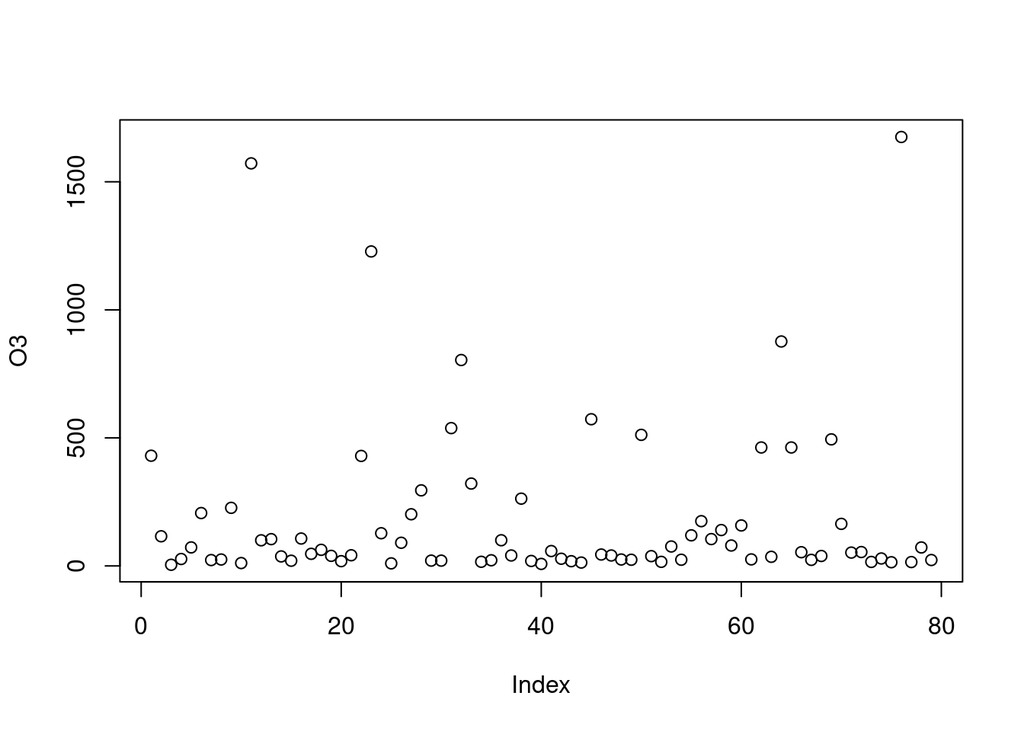

```r
# 1.3
## Pasemos ahora a un caso real
#Ejemplo pag. 15
#Máximos estivales del contaminante atmosférico O3
O3<-c(430.3, 115.7,4.48, 26.95, 72.27,206.4, 22.79,25.03,226.8,11.1,1572,100,104.5,37.1,20.22,106.9,47.2,62.82,39.3,18.52,41.57,429.5,1228,127.6,9.93,90.4,201.7,295.1,20.62,20.58,538.1,804,321.6,16.11,22.05,100.2,40.76,262.7,19.32,
7.79,58.02,28.02,18.38,13.12,572.8,44.46,40.72,25.07,24.07,511.8,38.12,15.86,75.84,24.09,119.4,174.7,104.7,140,79.67,158,25.46,462.5,35.53,876.4,462.5,53.47,23.59,38.77,494.2,164.2,52.06,54.13,15.53,29,14.35,1675,15.01,72.07,22.99)

plot(O3)
```

Vemos que hay algunos datos de máximos que se disparan, brindando pistas claras sobre la DEA candidata. Recuerden que debemos tener datos *iid*. Y por lo tanto es bueno evaluar si hay rachas. Esto lo haremos con la función *run.tests* del paquete *{snapar}*.

```r
require(snpar)
runs.test(O3, exact=FALSE)
```

```
##
##  Approximate runs rest
##
## data:  O3
## Runs = 44, p-value = 0.4271
## alternative hypothesis: two.sided
```

Vemos que no rechazamos la hipótesis nula de rachas. Continuando con la idea de ajustar una distribución extremal

¿Qué tipo de distribución extremal le parece que capture esta dinámica de máximos? ¿como se refleja en el indice de una GEV?

```r
# Ajustamos a estos datos por maxima verosimiliud una distribución extremal generalizada
modO3<-gev.fit(O3)
```

```
## $conv
## [1] 0
##
## $nllh
## [1] 468.9038
##
## $mle
## [1] 37.367980 41.931248  1.096984
##
## $se
## [1] 5.2378582 7.5503443 0.1421071
```

```r
# Exploremos que tiene dentro el objeto mod3
str(modO3)
```

```
## List of 10
##  $ trans: logi FALSE
##  $ model:List of 3
##   ..$ : NULL
##   ..$ : NULL
##   ..$ : NULL
##  $ link : chr "c(identity, identity, identity)"
##  $ conv : int 0
##  $ nllh : num 469
##  $ data : num [1:79] 430.3 115.7 4.48 26.95 72.27 ...
##  $ mle  : num [1:3] 37.4 41.9 1.1
##  $ cov  : num [1:3, 1:3] 27.435 34.442 -0.018 34.442 57.008 ...
##  $ se   : num [1:3] 5.238 7.55 0.142
##  $ vals : num [1:79, 1:3] 37.4 37.4 37.4 37.4 37.4 ...
##  - attr(*, "class")= chr "gev.fit"
```

```r
# Veamos el valor de los parametros ajustados por mve
modO3$mle
```

```
## [1] 37.367980 41.931248  1.096984
```

```r
# Resumen del ajuste (debo hacerlo manualmente pues no hay una funcion equivalente al summary)
data.frame(parameter=c("posicion", "escala","indice"), cbind(Estimate=modO3$mle, se=modO3$se))
```

```
##   parameter  Estimate        se
## 1  posicion 37.367980 5.2378582
## 2    escala 41.931248 7.5503443
## 3    indice  1.096984 0.1421071
```

El indice tiene un IdC que sugiere que es positivo, por lo que estamos ante posibles colas pesadas (como se intuia de ver la figura de los valores). Y es similar a la estimación generada por Gonzalo manualmente en la planilla (1.04).

Solo a modo de ejercicio, observemos que sucede con los parámetros cuando corremos toda la variable 15 unidades. ¿Cuál parámetro se verá afectado?

```r
modO3shift<-gev.fit(O3-15)
```

```
## $conv
## [1] 0
##
## $nllh
## [1] 468.9038
##
## $mle
## [1] 22.367980 41.931248  1.096984
##
## $se
## [1] 5.2378566 7.5503411 0.1421071
```

```r
data.frame(parameter=c("posicion", "escala","indice"), cbind(Estimate=modO3shift$mle, se=modO3shift$se))
```

```
##   parameter  Estimate        se
## 1  posicion 22.367980 5.2378566
## 2    escala 41.931248 7.5503411
## 3    indice  1.096984 0.1421071
```

### Grafiquemos el índice de las distribuciones que vimos hasta el momento.

Recordemos la interpretación del índice ($\xi$):
$$\xi < 0 => ~X \approx Weibull \\
\xi = 0 => ~X \approx Gumbell \\
\xi > 0 => ~X \approx Frechet \\$$

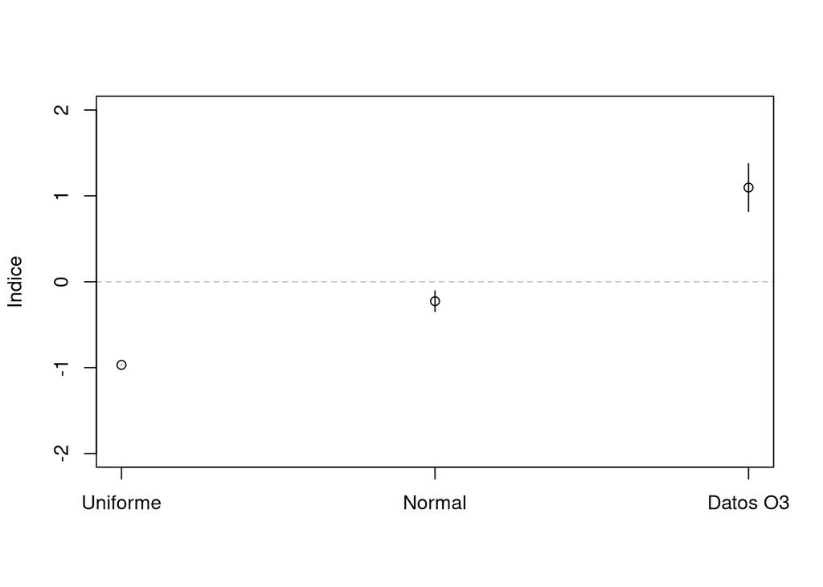

```r
# Grafico el valor del parámetro que determina cuan pesada es la cola de la distribución
#jpeg("indiceO3.jpeg", res=200, width=5,height=5, units="in") # Esta función jpeg permite exportar los gráficos.
plot(1:3, c(modUnif$mle[3], modNorm$mle[3], modO3$mle[3]), ylab="Indice", xlab="", ylim=c(-2,2), axes=FALSE)
segments(1, modUnif$mle[3]-(modUnif$se[3]*1.96), 1, modUnif$mle[3]+(modUnif$se[3]*1.96))
segments(2, modNorm$mle[3]-(modNorm$se[3]*1.96), 2, modNorm$mle[3]+(modNorm$se[3]*1.96))
segments(3, modO3$mle[3]-(modO3$se[3]*1.96), 3, modO3$mle[3]+(modO3$se[3]*1.96)) # notese que el intervalo es el IdC
abline(h=0,lty=2, col="grey")
axis(1, at=1:3, labels=c("Uniforme", "Normal", "Datos O3")); box(); axis(2)
```

```r
#dev.off()
```

### Niveles y tiempo de retorno

El período de retorno se calcula como el inverso de la probabilidad de excesos. Tomemos el ejemplo sintético de la distribución Normal para fijar conceptos. Aprovecharemos el caso para introducir un nuevo paquete interesante para el análisis de datos extremales (paquete {extRemes}). Recuerden que si no lo tienen instalado, deben hacerlo utilizando la función *install.packages()*.

```r
require(extRemes)
# Ajustemos la distribución extremal con el paquete extRemes y la función "fevd". Ajusto por Maxima verosimilitud
modNormext<-fevd(maxNorm)
modNormext$results$par
```

```
##   location      scale      shape
## 22.3373972  0.4216981 -0.2265683
```

```r
# nombro un vector con los parámetros ajustados
a<-modNormext$results$par
# comparamos con los resultados del ajuste que hicimos previamente
modNorm$mle
```

```
## [1] 22.3374486  0.4217606 -0.2266639
```

```r
# Estimemos el valor de retorno para los 10 años
return.level(modNormext, return.period = c(10), do.ci=TRUE)
```

```
## fevd(x = maxNorm)
##
## [1] "Normal Approx."
##
## [1] "10-year return level: 23.081"
##
## [1] "95% Confidence Interval: (22.9616, 23.2)"
```

El paquete {extRemes} nos permite visualizar los ajustes a distribuciones extremales y generar figuras para visualizar esto y los tiempos de retorno.

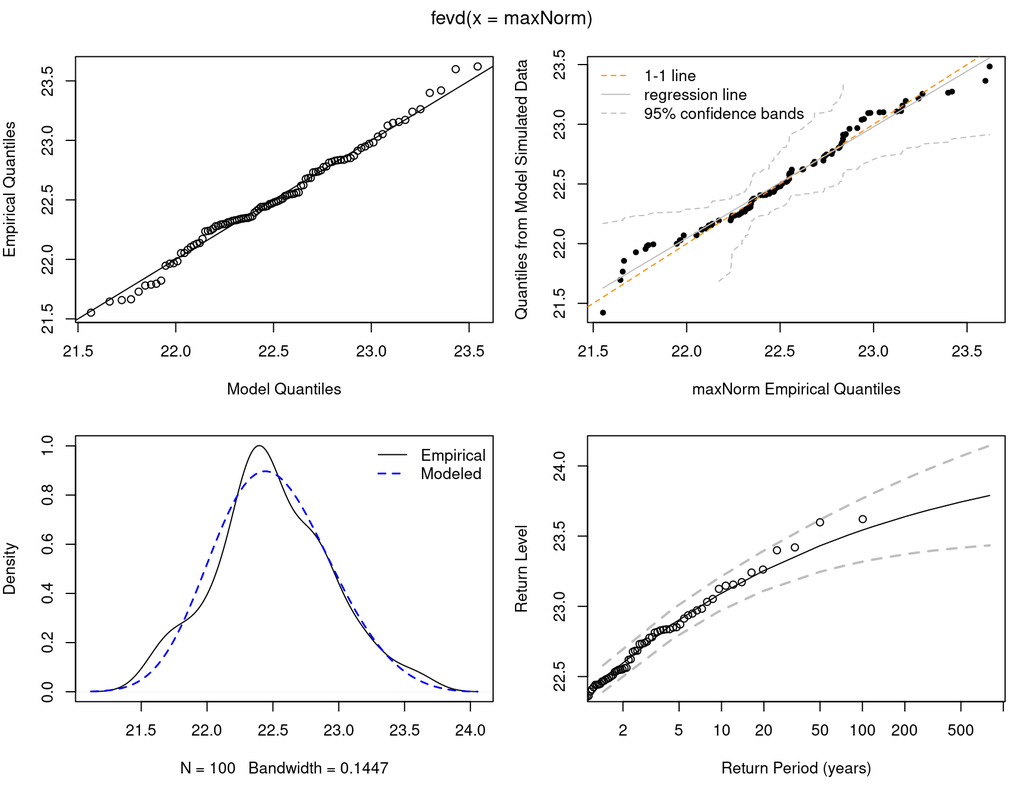

```r
# Podemos hacer varios plots diagnósticos y entre ellos ver los tiempos de retorno y los periodos de retorno
par(mar=c(5,4,1,1))
plot(modNormext)
```

## EJERCICIOS

### Ejercicio 1 del teórico (pg. 33 5)

1. Determinar si la distribución log-normal (log X es normal) tiene DEA y si la tiene, determinar cuál es su DEA
2. Con la ayuda de R simular una muestra de 100 datos iid, cada uno de los cuales es el máximo de 500 log-normales standard iid. Intente ajustar la distribución de la muestra de 100 datos de acuerdo a lo obtenido en a parte a)

### Ejercicio 2

Dados los datos de paso diario que se aportaron en “datsoEjercicio2.csv”

1. Graficar la serie con un gráfico de lineas
2. Tomar maximo semanal
3. Ajustar una distribución extremal generalizada
4. Cual es la distribución?
5. Graficar F(x) y f(x)
6. Calcular nivel de retorno para 52 semanas.

### Si realizó todo lo anterior sin problemas y cuenta con una base de datos propia, puede intentar estos ajustes.